# p8105_hw5_SC4934

Sophia Chkonia

2022-11-15

### Problem 0

```r
library(tidyverse)
library(ggplot2)
```

## Problem 1

```r
full_df =
  tibble(
    files = list.files("data/zip_data/"),
    path = str_c("data/zip_data/", files)
  ) %>%
  mutate(data = map(path, read_csv)) %>%
  unnest()
```

### To tidy the dataframe:

```r
tidy_df =
  full_df %>%
  mutate(
    files = str_replace(files, ".csv", ""),
    group = str_sub(files, 1, 3)) %>%
  pivot_longer(
    week_1:week_8,
    names_to = "week",
    values_to = "outcome",
    names_prefix = "week_") %>%
  mutate(week = as.numeric(week)) %>%
  select(group, subj = files, week, outcome)
```

### Spaghetti plot:

Make a spaghetti plot showing observations on each subject over time, and comment on differences between groups.

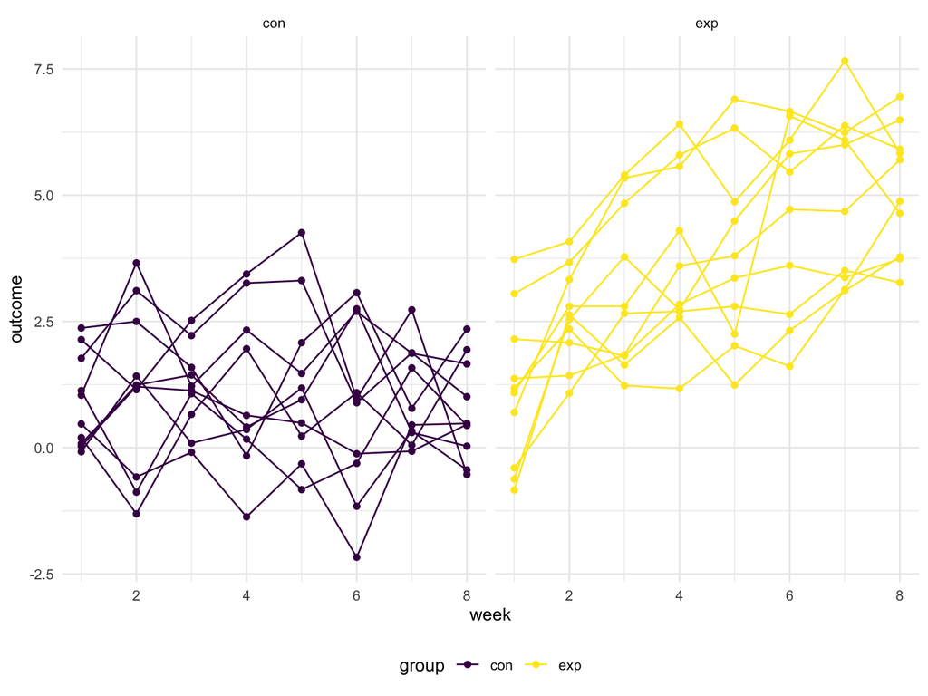

```r
tidy_df %>%
  ggplot(aes(x = week, y = outcome, group = subj, color = group)) +
  geom_point() +
  geom_path() +
  facet_grid(~group)
```

The path shows bigger change in outcome (linear increase) in the experimental group than the control group, where the outcome stays relatively the same through the weeks. The plot also shows high within-subject correlation, meaning that the subjects that are above average at the beginning of the observation period are above average at the end of the study period, and vice versa.

## Problem 2

```r
homicide =
read_csv(
  "data/homicide-data.csv"
) %>%
  janitor::clean_names() %>%
  mutate(
    state = case_when(city == "Tulsa" ~ "OK", TRUE ~ as.character(state)),
    city_state = str_c(city, ", ", state)) %>%
  group_by(city_state) %>%
  summarise(
    homicide = n(),
    unsolved = sum(disposition == "Closed without arrest" | disposition == "Open/No arrest")
  )
```

There appeared to be a mistake in the data where Tulsa, OK was input as Tulsa, AL, making the number of cities 51 instead of 50. As part of tidying the dataset I changed the state variable from AL to OK, before combining `city` and `state` into `city_state`, which corrected the error.

### Prop.test Baltimore

```r
Baltimore =
  homicide %>%
  filter(
    city_state == "Baltimore, MD"
  )

proptest =
  prop.test(
    x = Baltimore %>% pull(unsolved),
    n = Baltimore %>% pull(homicide),
    alternative = c("two.sided"),
    conf.level = 0.95, correct = TRUE
  ) %>%
  broom::tidy() %>%
  select(estimate, conf.low, conf.high)
```

### For each city

```r
each_city =
  homicide %>% mutate(
   newcol = purrr::map2(unsolved, homicide, prop.test),
   estimate = map_dbl(newcol, ~ .x[["estimate"]]),
   CI = map(newcol, ~as.numeric(.x[["conf.int"]]))
  ) %>%
  separate(CI, into = c("conf.low", "conf.high"), sep = ", ") %>%
  mutate(
    conf.low = str_sub(conf.low, 3, 11),
    conf.high = str_sub(conf.high, 1, 9),
    ) %>%
  select(
    city_state, estimate, conf.low, conf.high
  )
```

### Plot

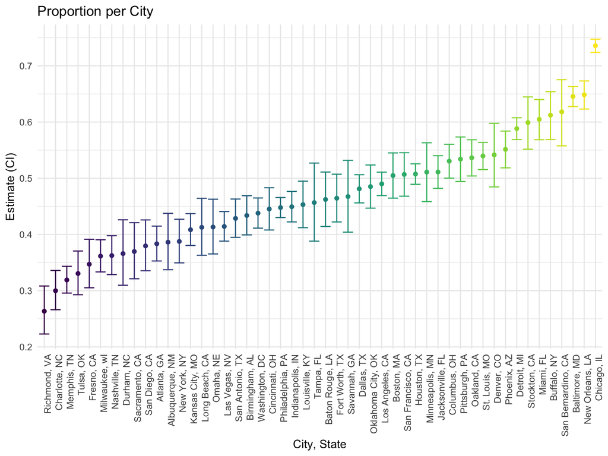

```r
each_city %>%
  mutate(city_state = fct_reorder(city_state, estimate)) %>%
  ggplot(aes(x = city_state, y = estimate, color = city_state)) +
  geom_point() +
  geom_errorbar(aes(ymin = as.numeric(conf.low), ymax = as.numeric(conf.high))) +
  labs(
    x = "City, State",
    y = "Estimate (CI)",
    title = "Proportion per City"
  ) +
    theme(axis.text.x = element_text(angle = 90, hjust = 1)) +
  theme(legend.position = "none")
```

## Problem 3

```r
set.seed(1)

sim_t_test = function(mu){
sample = rnorm(30, mu, sd = 5)
test_results = t.test(sample) %>%
  broom::tidy()
}


# 5000 iterations when mu = 0
sim_results_df_0 =
  expand_grid(
    mu = 0,
    iter = 1:5000
  ) %>%
  mutate(
    estimate_df = map(mu, sim_t_test)
  ) %>%
  unnest(estimate_df)

# Repeat for mu = 1 : 6

sim_results_df_1to6 =
  expand_grid(
    mu = c(1:6),
    iter = 1:5000
  ) %>%
  mutate(
    estimate_df = map(mu, sim_t_test)
  ) %>%
  unnest(estimate_df)

# Final repeat for mu = 0 : 6
sim_results_df =
  expand_grid(
    mu = c(0:6),
    iter = 1:5000
  ) %>%
  mutate(
    estimate_df = map(mu, sim_t_test)
  ) %>%
  unnest(estimate_df)
```

### Plot

```r
Power_vs_mu =
  sim_results_df %>%
  mutate(
    status = ifelse(p.value < 0.05, TRUE, FALSE)
  ) %>%
  group_by(mu) %>%
  summarise(power = sum(status)/5000) %>%
  ggplot(aes(x = mu, y = power)) +
  geom_point(aes(color = mu)) +
  geom_line(alpha = .5) +
  labs(
    title = "Power vs True Mean",
    x = "True Mean",
    y = "Power"
  )
```

[output not shown]

### Second Plot

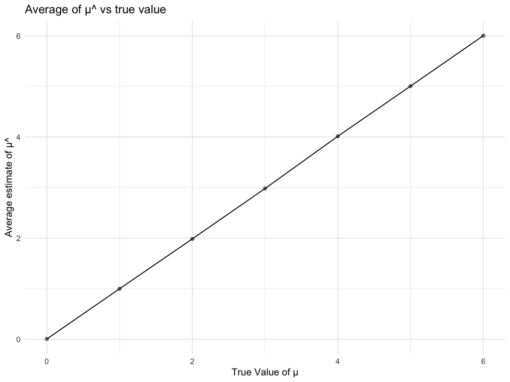

```r
all =
  sim_results_df %>%
  group_by(mu) %>%
  summarise(all_mean = mean(estimate)) %>%
  ggplot(aes(x = mu, y = all_mean)) +
  geom_point(alpha = 0.5) +
  geom_line()+
  labs(
    title = "Average of μ^ vs true value ",
    x = "True Value of μ",
    y = "Average estimate of μ^"
  )


reject =
  sim_results_df %>%
  mutate(
    status = ifelse(p.value < 0.05, TRUE, FALSE)
  ) %>%
  group_by(mu) %>%
  filter(status == TRUE) %>%
  summarise(reject_mean = mean(estimate)) %>%
  ggplot(aes(x = mu, y = reject_mean)) +
  geom_point(alpha = 0.5) +
  geom_line() +
  labs(
    title = "Average of μ^ in rejected null vs true value ",
    x = "True Value of μ",
    y = "Average estimate of μ^"
  )

# Plots:
all
```

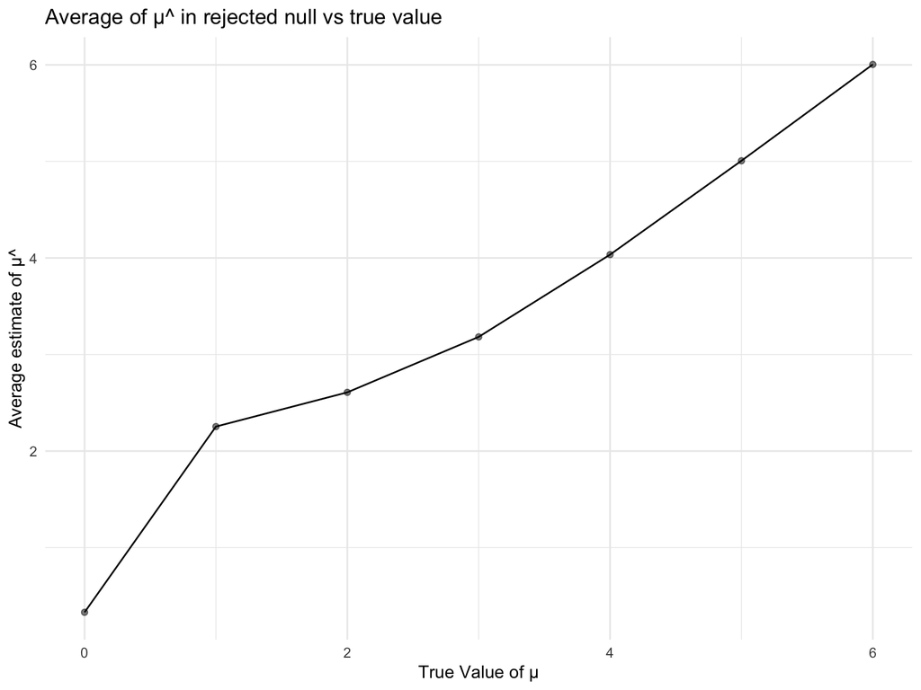

```r
reject
```

The sample average of μ̂ across tests for which the null is rejected does not match the true value of μ, especially when there is low power. This could be because if you only look at results that reject the null, so only significant results, those results will not match the true value of μ. This is especially true with low power or low sample size.